# Possible COVID-19 Infection Trajectories in South Africa

Rendani Mbuvha, Tshilidzi Marwala

3/24/2020

This notebook aims to provide some initial high-level forecasting of the progression of COVID-19 in South Africa by drawing lessons from progression in other countries. **At the moment given the sparse data, the aim is not forecasting precision but scenario mapping.**

Essentially, this notebook tries to use simple curve fitting methods to answer the questions: What would happen in the next 60 days if South Africa’s COVID-19 infections followed the infection trajectory of:

- China
- Italy
- South Korea
- Iran
- The “World” (global average)

Another question we try to answer is what if we use Facebook’s [Prophet](https://facebook.github.io/prophet/) model to forecast South Africa’s trajectory.

**Note to reader** - All models are fitted on cases per million and then scaled up to SA’s population at the end.

## Loading the relevent libraries

## Reading in the Data

The data included in this analysis is upto and including the 24th of March 2020

```r
total_cases = read.csv("total_cases.csv")
total_cases_per_mil = read.csv("total_cases_per_mil.csv")
total_cases_per_mil_adj = read.csv("total_cases_per_mil_test_adj.csv")
total_cases_per_mil_adj_expand = read.csv("total_cases_per_mil_test_adj_expand.csv")
population = read.csv("poputlation.csv")
index = seq(1,85)
total_cases_per_mil_adj =cbind(total_cases_per_mil_adj,index)
```

## Initial High-level Plots

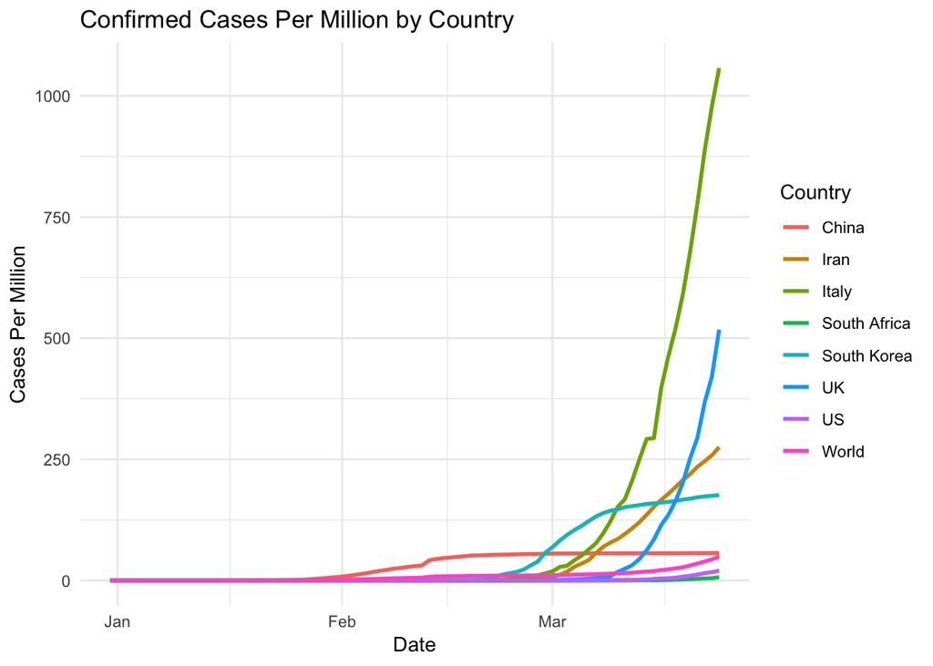

```r
total_cases_per_mil_adj_expand$date = as.Date(total_cases_per_mil_adj_expand$date, format = "%d/%m/%Y")
ggplot(total_cases_per_mil_adj_expand[1:680,], aes(x = date, y = Confirmed_Cases)) +
  geom_line(aes(color = Country), size = 1) +
    xlab("Date") + ylab("Cases Per Million")+
  ggtitle("Confirmed Cases Per Million by Country")+
  theme_minimal()
```

Observations

- Italy has huge problems
- China and South Korea have managed to flatten the curve
- Iran seems to be working hard on this
- UK should be worried but… they test more than the average!
- SA(and the ‘World’) looks okay for now – We did adjust for lower testing in SA(this seems to increase cases by about 2% *i.e if SA was testing similar to global average*).

## Facebook Prophet time series forecasting model on South African Data

These model seems to require more data or perhaps a saturation point to be predefined. Perhaps we must return next month(more data)??

```
## Disabling yearly seasonality. Run prophet with yearly.seasonality=TRUE to override this.
```

```
## Disabling daily seasonality. Run prophet with daily.seasonality=TRUE to override this.
```

Create future periods for South Africa i.e next 60 days

Make Predictions for South Africa

```r
sa_forecast = predict(sa_model , sa_future)
tail(sa_forecast[c('ds', 'yhat', 'yhat_lower', 'yhat_upper')])
```

```
##            ds     yhat yhat_lower yhat_upper
## 74 2020-05-18 1212.058   1150.632   1274.161
## 75 2020-05-19 1259.718   1190.557   1325.584
## 76 2020-05-20 1210.009   1141.632   1272.489
## 77 2020-05-21 1228.510   1165.793   1295.290
## 78 2020-05-22 1281.230   1215.245   1345.556
## 79 2020-05-23 1301.901   1238.909   1370.057
```

### Plot South Africa’s Forecasts

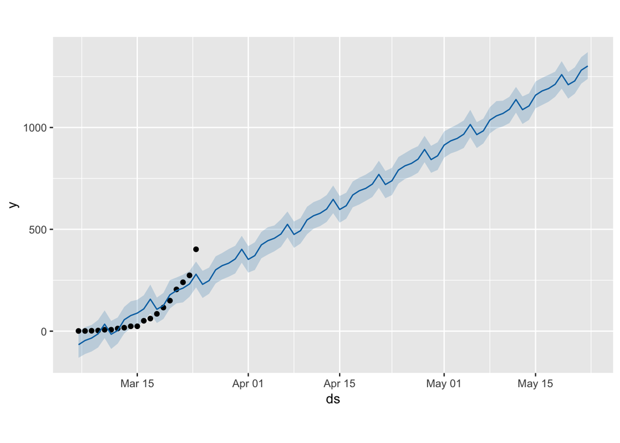

```r
plot(sa_model, sa_forecast)
```

```r
sa_forecast_exp = exp(sa_forecast[c( 'yhat', 'yhat_lower', 'yhat_upper')])
```

```r
sa_future$time <- seq.int(nrow(sa_future))
sa_data$time <- seq.int(nrow(sa_data))
sa_data_2$time <- seq.int(nrow(sa_data_2))
sk_data$time <- seq.int(nrow(sk_data))
iran_data$time <- seq.int(nrow(iran_data))
china_data$time <- seq.int(nrow(china_data))
italy_data$time <- seq.int(nrow(italy_data))
world_data$time <- seq.int(nrow(world_data))
```

## Curve Fitting

### Second-order polynomial

```r
world_2o= lm(y~poly(time-1,2,raw=TRUE),data = world_data)
china_2o= lm(y~poly(time-1,2,raw=TRUE), data = china_data)
italy_2o= lm(y~poly(time-1,2,raw=TRUE), data = italy_data)
iran_2o= lm(y~poly(time-1,2,raw=TRUE), data = iran_data)
south_korea_2o= lm(y~poly(time-1,2,raw=TRUE), data = sk_data)
south_africa_2o= lm(y~poly(time-1,2,raw=TRUE), data = sa_data)
```

### Goodness of Fit

with an R_squared of 0.97 this model is not bad i.e caputure 97% of variance in the current data

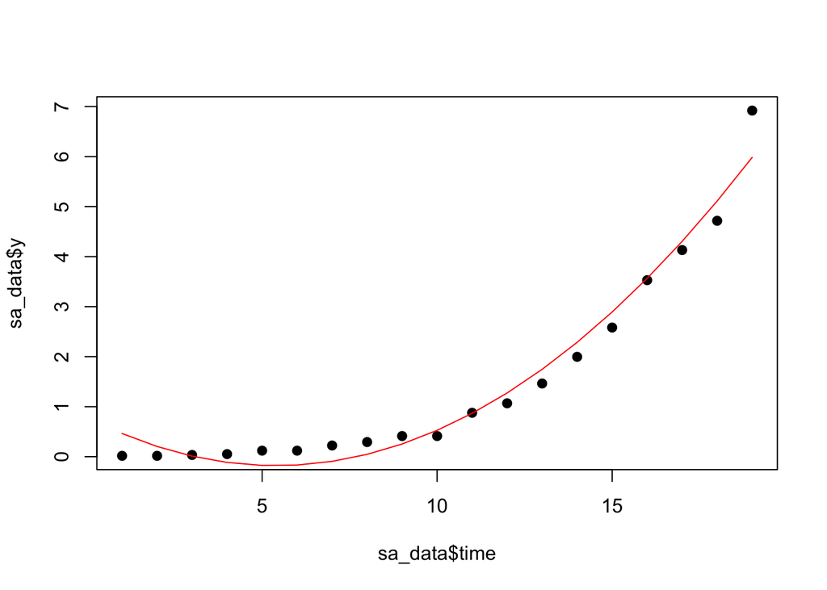

```r
plot(sa_data$time,sa_data$y,pch=19)
lines(sa_data$time,predict(south_africa_2o,sa_data),col="red")
```

```r
summary(south_africa_2o)
```

```
##
## Call:
## lm(formula = y ~ poly(time - 1, 2, raw = TRUE), data = sa_data)
##
## Residuals:
##      Min       1Q   Median       3Q      Max
## -0.44607 -0.24483 -0.03665  0.20603  0.93628
##
## Coefficients:
##                                 Estimate Std. Error t value Pr(>|t|)
## (Intercept)                     0.463286   0.219667   2.109   0.0511 .
## poly(time - 1, 2, raw = TRUE)1 -0.292492   0.056578  -5.170 9.31e-05 ***
## poly(time - 1, 2, raw = TRUE)2  0.033285   0.003034  10.971 7.45e-09 ***
## ---
## Signif. codes:  0 '***' 0.001 '**' 0.01 '*' 0.05 '.' 0.1 ' ' 1
##
## Residual standard error: 0.3534 on 16 degrees of freedom
## Multiple R-squared:  0.9717, Adjusted R-squared:  0.9682
## F-statistic: 274.8 on 2 and 16 DF,  p-value: 4.1e-13
```

### Making Predictions Based On Other Countries(second-order polynomial)

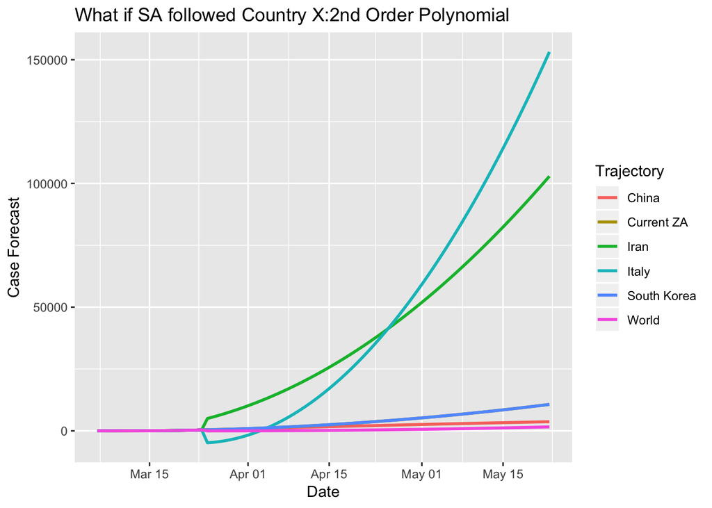

```r
ggplot(o2_pred_data_frame, aes(x = date, y = forecast)) +
  geom_line(aes(color = Trajectory), size = 1) +
    xlab("Date") + ylab("Case Forecast")+
    ggtitle("What if SA followed Country X:2nd Order Polynomial")
```

```r
  #geom_hline(yintercept=120000, linetype="dashed", color = "red")
```

## Italy and Iran skew things lets not show them …

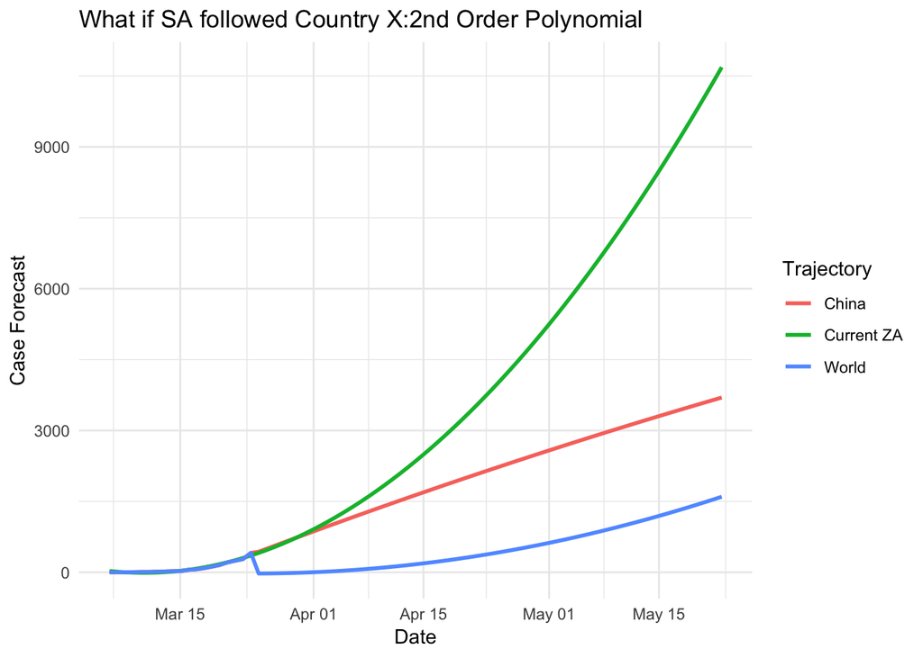

```r
ggplot(o2_pred_data_frame, aes(x = date, y = forecast)) +
  geom_line(aes(color = Trajectory), size = 1) +
    xlab("Date") + ylab("Case Forecast")+
  ggtitle("What if SA followed Country X:2nd Order Polynomial")+
  theme_minimal()
```

## Gaussian Process

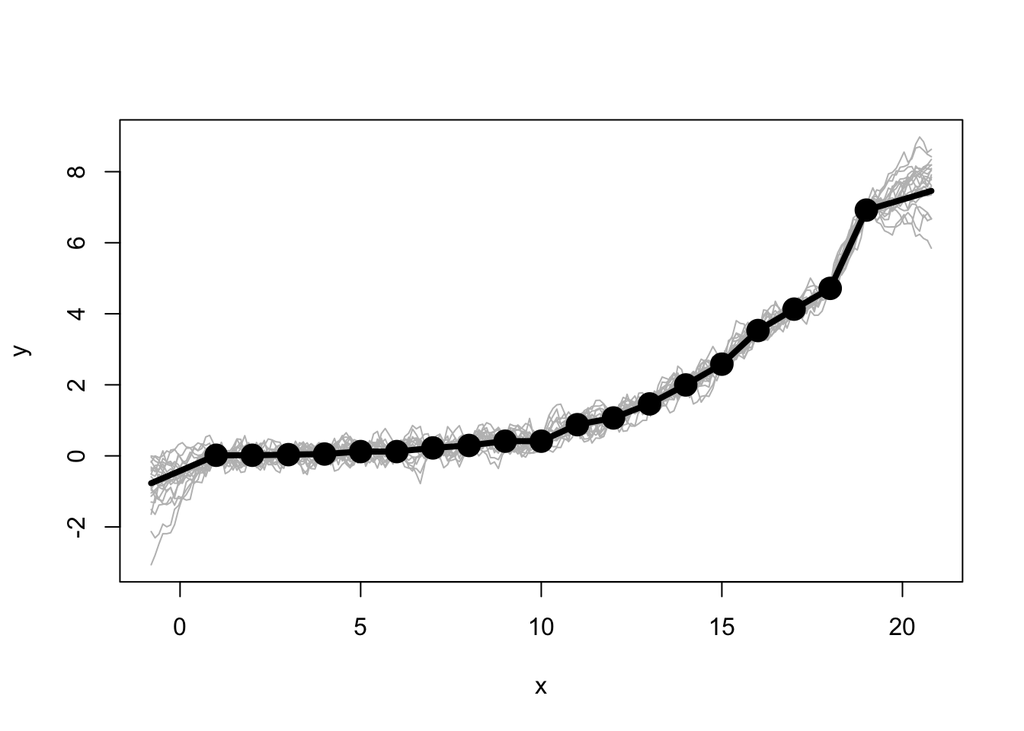

```r
kern.exp = Exponential$new(0)
trend.0 = trend_LM$new(D=1)
gpk.exp = GauPro_kernel_model$new(sa_data$time, sa_data$y, kernel=kern.exp, trend=trend.0, parallel=FALSE)
plot(gpk.exp)
```

```r
gp_pred = predict(gpk.exp, sa_future$time,se.fit = T)*population[5,2]/1000000

gp_plot_data =cbind(sa_future,gp_pred)
```

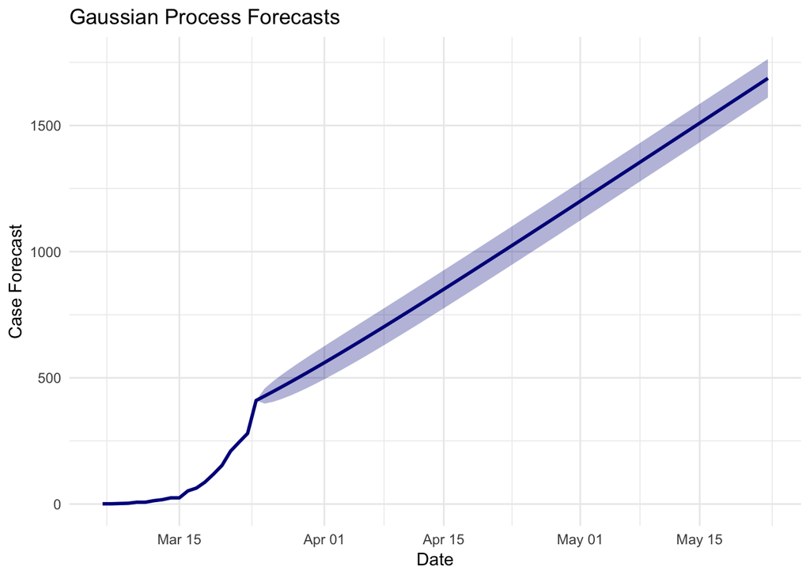

```r
ggplot(gp_plot_data, aes(x = ds, y = mean)) +
  geom_line(color='darkblue', size = 1) +
    xlab("Date") + ylab("Case Forecast")+
  ggtitle("Gaussian Process Forecasts")+
    geom_ribbon(data=gp_plot_data,aes(ymin=mean-se,ymax=mean+se),fill='darkblue',alpha=0.3)+
theme_minimal()
```

## Aggregation of all Forecasts

```r
Agg_table =cbind(sa_future$ds,as.data.frame(south_africa_2o_predictions$forecast),as.data.frame(china_2o_predictions$forecast),as.data.frame(iran_2o_predictions$forecast),as.data.frame(sa_forecast$yhat),as.data.frame(gp_pred$mean))
colnames(Agg_table)=c("date","Polynomial ZA","Polynomial China","Polynomial Iran","FB Prophet","Gaussian Process")
kable(Agg_table[8:79,])
```

|  | date | Polynomial ZA | Polynomial China | Polynomial Iran | FB Prophet | Gaussian Process |
| --- | --- | --- | --- | --- | --- | --- |
| 8 | 2020-03-13 | 2.775679 | 17.35341 | 17.35341 | 56.03436 | 17.35341 |
| 9 | 2020-03-14 | 15.039593 | 24.49893 | 24.49893 | 76.70462 | 24.49893 |
| 10 | 2020-03-15 | 31.251671 | 24.49893 | 24.49893 | 88.71167 | 24.49894 |
| 11 | 2020-03-16 | 51.411913 | 52.06023 | 52.06023 | 109.38192 | 52.06023 |
| 12 | 2020-03-17 | 75.520319 | 63.28891 | 63.28891 | 157.04137 | 63.28891 |
| 13 | 2020-03-18 | 103.576889 | 86.76706 | 86.76706 | 107.33259 | 86.76706 |
| 14 | 2020-03-19 | 135.581623 | 118.41151 | 118.41151 | 125.83381 | 118.41151 |
| 15 | 2020-03-20 | 171.534522 | 153.11833 | 153.11833 | 178.55397 | 153.11834 |
| 16 | 2020-03-21 | 211.435584 | 209.26172 | 209.26172 | 199.22423 | 209.26172 |
| 17 | 2020-03-22 | 255.284810 | 244.98933 | 244.98933 | 211.23128 | 244.98933 |
| 18 | 2020-03-23 | 303.082200 | 279.69616 | 279.69616 | 231.90153 | 279.69616 |
| 19 | 2020-03-24 | 354.827755 | 410.35714 | 410.35714 | 279.56098 | 410.35713 |
| 20 | 2020-03-25 | 410.521473 | 435.27252 | 4999.31937 | 229.85220 | 427.97639 |
| 21 | 2020-03-26 | 470.163356 | 497.50956 | 5628.48565 | 248.35342 | 445.96630 |
| 22 | 2020-03-27 | 533.753402 | 559.50694 | 6293.18752 | 301.07358 | 464.29700 |
| 23 | 2020-03-28 | 601.291613 | 621.26468 | 6993.42499 | 321.74384 | 482.94101 |
| 24 | 2020-03-29 | 672.777987 | 682.78275 | 7729.19807 | 333.75089 | 501.87309 |
| 25 | 2020-03-30 | 748.212525 | 744.06117 | 8500.50675 | 354.42114 | 521.07001 |
| 26 | 2020-03-31 | 827.595228 | 805.09994 | 9307.35104 | 402.08059 | 540.51044 |
| 27 | 2020-04-01 | 910.926095 | 865.89905 | 10149.73092 | 352.37181 | 560.17473 |
| 28 | 2020-04-02 | 998.205125 | 926.45851 | 11027.64641 | 370.87303 | 580.04486 |
| 29 | 2020-04-03 | 1089.432320 | 986.77831 | 11941.09750 | 423.59319 | 600.10423 |
| 30 | 2020-04-04 | 1184.607679 | 1046.85846 | 12890.08419 | 444.26345 | 620.33758 |
| 31 | 2020-04-05 | 1283.731202 | 1106.69895 | 13874.60649 | 456.27050 | 640.73090 |
| 32 | 2020-04-06 | 1386.802888 | 1166.29979 | 14894.66438 | 476.94075 | 661.27130 |
| 33 | 2020-04-07 | 1493.822739 | 1225.66097 | 15950.25788 | 524.60020 | 681.94691 |
| 34 | 2020-04-08 | 1604.790754 | 1284.78250 | 17041.38699 | 474.89142 | 702.74684 |
| 35 | 2020-04-09 | 1719.706933 | 1343.66437 | 18168.05169 | 493.39264 | 723.66107 |
| 36 | 2020-04-10 | 1838.571276 | 1402.30659 | 19330.25200 | 546.11280 | 744.68038 |
| 37 | 2020-04-11 | 1961.383783 | 1460.70916 | 20527.98791 | 566.78306 | 765.79632 |
| 38 | 2020-04-12 | 2088.144454 | 1518.87206 | 21761.25942 | 578.79011 | 787.00109 |
| 39 | 2020-04-13 | 2218.853289 | 1576.79532 | 23030.06653 | 599.46036 | 808.28752 |
| 40 | 2020-04-14 | 2353.510288 | 1634.47892 | 24334.40925 | 647.11981 | 829.64905 |
| 41 | 2020-04-15 | 2492.115451 | 1691.92286 | 25674.28757 | 597.41103 | 851.07961 |
| 42 | 2020-04-16 | 2634.668778 | 1749.12715 | 27049.70149 | 615.91225 | 872.57364 |
| 43 | 2020-04-17 | 2781.170269 | 1806.09178 | 28460.65101 | 668.63241 | 894.12603 |
| 44 | 2020-04-18 | 2931.619925 | 1862.81676 | 29907.13614 | 689.30267 | 915.73207 |
| 45 | 2020-04-19 | 3086.017744 | 1919.30209 | 31389.15687 | 701.30972 | 937.38744 |
| 46 | 2020-04-20 | 3244.363727 | 1975.54776 | 32906.71320 | 721.97997 | 959.08816 |
| 47 | 2020-04-21 | 3406.657875 | 2031.55377 | 34459.80513 | 769.63942 | 980.83058 |
| 48 | 2020-04-22 | 3572.900186 | 2087.32013 | 36048.43267 | 719.93064 | 1002.61134 |
| 49 | 2020-04-23 | 3743.090661 | 2142.84684 | 37672.59581 | 738.43186 | 1024.42734 |
| 50 | 2020-04-24 | 3917.229301 | 2198.13389 | 39332.29455 | 791.15202 | 1046.27575 |
| 51 | 2020-04-25 | 4095.316104 | 2253.18129 | 41027.52889 | 811.82228 | 1068.15396 |
| 52 | 2020-04-26 | 4277.351072 | 2307.98903 | 42758.29884 | 823.82932 | 1090.05955 |
| 53 | 2020-04-27 | 4463.334203 | 2362.55711 | 44524.60439 | 844.49958 | 1111.99033 |
| 54 | 2020-04-28 | 4653.265499 | 2416.88554 | 46326.44554 | 892.15903 | 1133.94427 |
| 55 | 2020-04-29 | 4847.144958 | 2470.97432 | 48163.82229 | 842.45025 | 1155.91950 |
| 56 | 2020-04-30 | 5044.972582 | 2524.82344 | 50036.73464 | 860.95147 | 1177.91429 |
| 57 | 2020-05-01 | 5246.748370 | 2578.43291 | 51945.18260 | 913.67163 | 1199.92709 |
| 58 | 2020-05-02 | 5452.472321 | 2631.80272 | 53889.16616 | 934.34189 | 1221.95642 |
| 59 | 2020-05-03 | 5662.144437 | 2684.93288 | 55868.68532 | 946.34893 | 1244.00097 |
| 60 | 2020-05-04 | 5875.764717 | 2737.82338 | 57883.74009 | 967.01919 | 1266.05951 |
| 61 | 2020-05-05 | 6093.333161 | 2790.47422 | 59934.33046 | 1014.67864 | 1288.13090 |
| 62 | 2020-05-06 | 6314.849769 | 2842.88542 | 62020.45642 | 964.96986 | 1310.21412 |
| 63 | 2020-05-07 | 6540.314540 | 2895.05695 | 64142.11800 | 983.47108 | 1332.30820 |
| 64 | 2020-05-08 | 6769.727476 | 2946.98884 | 66299.31517 | 1036.19124 | 1354.41228 |
| 65 | 2020-05-09 | 7003.088576 | 2998.68107 | 68492.04795 | 1056.86150 | 1376.52554 |
| 66 | 2020-05-10 | 7240.397840 | 3050.13364 | 70720.31633 | 1068.86854 | 1398.64726 |
| 67 | 2020-05-11 | 7481.655268 | 3101.34656 | 72984.12031 | 1089.53880 | 1420.77673 |
| 68 | 2020-05-12 | 7726.860860 | 3152.31982 | 75283.45989 | 1137.19825 | 1442.91335 |
| 69 | 2020-05-13 | 7976.014616 | 3203.05343 | 77618.33508 | 1087.48947 | 1465.05654 |
| 70 | 2020-05-14 | 8229.116536 | 3253.54738 | 79988.74587 | 1105.99069 | 1487.20575 |
| 71 | 2020-05-15 | 8486.166621 | 3303.80168 | 82394.69226 | 1158.71085 | 1509.36052 |
| 72 | 2020-05-16 | 8747.164869 | 3353.81632 | 84836.17425 | 1179.38110 | 1531.52039 |
| 73 | 2020-05-17 | 9012.111281 | 3403.59131 | 87313.19185 | 1191.38815 | 1553.68495 |
| 74 | 2020-05-18 | 9281.005857 | 3453.12665 | 89825.74505 | 1212.05840 | 1575.85383 |
| 75 | 2020-05-19 | 9553.848598 | 3502.42233 | 92373.83385 | 1259.71786 | 1598.02667 |
| 76 | 2020-05-20 | 9830.639502 | 3551.47835 | 94957.45825 | 1210.00908 | 1620.20315 |
| 77 | 2020-05-21 | 10111.378570 | 3600.29472 | 97576.61826 | 1228.51030 | 1642.38299 |
| 78 | 2020-05-22 | 10396.065803 | 3648.87143 | 100231.31387 | 1281.23046 | 1664.56590 |
| 79 | 2020-05-23 | 10684.701199 | 3697.20849 | 102921.54508 | 1301.90071 | 1686.75165 |